# Biostat 200C Final

Due Fri. June 13, 2025 @ 11:59PM

Published

June 13, 2025

This is a take-home and an open book final. Helping or asking help from others is considered plagiarism.

## 1 Q1 (25 pts). Longitudinal data analysis

Onychomycosis, popularly known as toenail fungus, is a fairly common condition that not only can disfigure and sometimes destroy the nail but that also can lead to social and self-image issues for sufferers. Tight-fitting shoes or hosiery, the sharing of common facilities such as showers and locker rooms, and toenail polish are all thought to be implicated in the development of onychomycosis. This question relates to data from a study conducted by researchers that recruited sufferers of a particular type of onychomycosis, dermatophyte onychomycosis. The study conducted by the researchers was focused on comparison of two oral medications, terbinafine (given as 250 mg/day, denoted as treatment 1 below) and itraconazole (given as 200 mg/day, denoted as treatment 2 below).

The trial was conducted as follows. 200 sufferers of advanced toenail dermatophyte onychomycosis in the big toe were recruited, and each saw a physician, who removed the afflicted nail. Each subject was then randomly assigned to treatment with either terbinafine (treatment 1) or itraconazole (treatment 2). Immediately prior to beginning treatment, the length of the unafflicted part of the toenail (which was hence not removed) was recorded (in millimeters). Then at 1 month, 2 months, 3 months, 6 months, and 12 months, each subject returned, and the length of the unafflicted part of the nail was measured again. A longer unafflicted nail length is a better outcome. Also recorded on each subject was gender and an indicator of the frequency with which the subject visited a gym or health club (and hence might use shared locker rooms and/or showers).

The data are available in the file `toenail.txt` from [here](https://github.com/ucla-biostat-200c/2025spring/tree/master/hw/datasets). The data are presented in the form of one data record per observation; the columns of the data set are as follows:

1. Subject id
2. Health club frequency indicator (= 0 if once a week or less, = 1 if more than once a week)
3. Gender indicator (= 0 if female, = 1 if male)
4. Month
5. Unafflicted nail length (the response, mm)
6. Treatment indicator (= 1 if terbinafine, = 2 if itraconazole)

The researchers had several questions, which they stated to you as follows:

Use the linear mixed effect model (LMM) to answer: Is there a difference in the pattern of change of lengths of the unafflicted part of the nail between subjects receiving terbinafine and itraconazole over a 12 month period? Does one treatment show results more quickly?

1. Plot the change of lengths of the unafflicted part of the nail over time and separated by treatment groups. Comment on overall patterns over time.
2. Based on the pattern observed, pick appropriate time trend in the LMM and provide an algebraic definition for your chosen LMM, e.g., is the linear trend model adequate? or quadratic trend is needed? or any other pattern is more approriate? justify your answer.
3. Model the covariance: fit both random intercept and random slope model and determine which one fits the data better.

In answering these scientific questions of interest, clearly write out the analytic models you consider for answering these questions (as detailed in the sub-questions). Clearly outline your decision making process for how you selected your final models. Fit your chosen final models and report to the project investigators on the stated scientific questions of interest.

## 2 Q2 (25 pts). GEE and GLMM

The Skin Cancer Prevention Study, a randomized, double-blind, placebo-controlled clinical trial, was designed to test the effectiveness of beta-carotene in the prevention of non-melanoma skin cancer in high-risk subjects. A total of 1,683 subjects were randomized to either placebo or 50mg of beta-carotene per day and were followed for up to 5 years. Subjects were examined once per year and biopsied if a cancer was suspected to determine the number of new cancers per year. The outcome variable, $Y$, is a count of the number of new skin cancers per year. You may assume that the counts of new skin cancers, $Y$, are from exact one-year periods (so that no offset term is needed).

Selected data from the study are in the dataset called `skin.txt` and is available [here](https://github.com/ucla-biostat-200c/2025spring/tree/master/hw/datasets). Each row of the dataset contains the following 9 variables: ID, Center, Age, Skin, Gender, Exposure, $Y$, Treatment, Year. These variables take values as follows:

| Variable |  |
| --- | --- |
| **ID**: | Subject identifier number |
| **Center**: | Identifier number for center of enrollment |
| **Age:** | Subject’s age in years at randomization |
| **Skin:** | Skin type (1=burns; 0 otherwise) [evaluated at randomization and doesn’t change with time] |
| **Gender:** | 1=male; 0=female |
| **Exposure:** | Count of number of previous skin cancers [prior to randomization] |
| **$Y$:** | Count of number of new skin cancers in the Year of follow-up |
| **Treatment:** | 1=beta-carotene; 0=placebo |
| **Year:** | Year of follow-up after starting randomized treatment |

Your collaborator is interested in assessing the effect of treatment on the incidence of new skin cancers over time. As the statistician on the project, provide an analysis of the data that addresses this question. Specifically, the investigator at Center=1 is interested in characterizing the distribution of risk among subjects at her center. In the following, only include the subset of subjects with Center=1 in the analysis.

Reorganizing and printing out the first few rows of the dataset (skin_data):

```r
skin_data <- read.table("~/Downloads/skin.txt", header = FALSE)
colnames(skin_data) <- c("ID", "Center", "Age", "Skin", "Gender",
                         "Exposure", "Y", "Treatment", "Year")
head(skin_data)
```

```
      ID Center Age Skin Gender Exposure Y Treatment Year
1 100034      1  51    1      1        4 0         0    1
2 100034      1  51    1      1        4 1         0    2
3 100034      1  51    1      1        4 1         0    3
4 100034      1  51    1      1        4 1         0    4
5 100034      1  51    1      1        4 0         0    5
6 100045      1  68    1      0        2 0         0    1
```

Reorganizing and printing out the first few rows of the dataset (new_skin) which filters out the rows with Center = 1.

```r
new_skin<- skin_data %>% filter(Center == 1)
str(new_skin)
```

```
'data.frame':   1883 obs. of  9 variables:
 $ ID       : int  100034 100034 100034 100034 100034 100045 100045 100045 100045 100045 ...
 $ Center   : int  1 1 1 1 1 1 1 1 1 1 ...
 $ Age      : int  51 51 51 51 51 68 68 68 68 68 ...
 $ Skin     : int  1 1 1 1 1 1 1 1 1 1 ...
 $ Gender   : int  1 1 1 1 1 0 0 0 0 0 ...
 $ Exposure : int  4 4 4 4 4 2 2 2 2 2 ...
 $ Y        : int  0 1 1 1 0 0 0 0 0 0 ...
 $ Treatment: int  0 0 0 0 0 0 0 0 0 0 ...
 $ Year     : int  1 2 3 4 5 1 2 3 4 5 ...
```

```r
summary(new_skin)
```

```
       ID             Center       Age             Skin           Gender
 Min.   :100012   Min.   :1   Min.   :31.00   Min.   :0.000   Min.   :0.0000
 1st Qu.:101996   1st Qu.:1   1st Qu.:58.00   1st Qu.:0.000   1st Qu.:0.0000
 Median :104701   Median :1   Median :65.00   Median :0.000   Median :1.0000
 Mean   :104634   Mean   :1   Mean   :63.75   Mean   :0.401   Mean   :0.6054
 3rd Qu.:106988   3rd Qu.:1   3rd Qu.:70.50   3rd Qu.:1.000   3rd Qu.:1.0000
 Max.   :110540   Max.   :1   Max.   :83.00   Max.   :1.000   Max.   :1.0000
    Exposure            Y            Treatment           Year
 Min.   : 1.000   Min.   :0.0000   Min.   :0.0000   Min.   :1.000
 1st Qu.: 1.000   1st Qu.:0.0000   1st Qu.:0.0000   1st Qu.:2.000
 Median : 2.000   Median :0.0000   Median :0.0000   Median :3.000
 Mean   : 2.598   Mean   :0.1593   Mean   :0.4843   Mean   :2.824
 3rd Qu.: 3.000   3rd Qu.:0.0000   3rd Qu.:1.0000   3rd Qu.:4.000
 Max.   :21.000   Max.   :7.0000   Max.   :1.0000   Max.   :5.000
```

```r
head(new_skin)
```

```
      ID Center Age Skin Gender Exposure Y Treatment Year
1 100034      1  51    1      1        4 0         0    1
2 100034      1  51    1      1        4 1         0    2
3 100034      1  51    1      1        4 1         0    3
4 100034      1  51    1      1        4 1         0    4
5 100034      1  51    1      1        4 0         0    5
6 100045      1  68    1      0        2 0         0    1
```

1. Provide an algebraic definition for a generalized linear marginal model (GEE) in which the only effects are for the intercept and Year (as a continuous variable). Fit this model and provide a table which includes the estimates of the parameters in your model.

**Solution**

**Algebraic Definition for the Generalized Linear Marginal Model (GEE):**

The fitted generalized estimating equations (GEE) model models the log of population-average expected rate of new skin cancers per one year follow up period. The model fitted is also a Poisson log-linear marginal model with an exchangeable correlation structure (for repeated measures within subjects).

Algebraic form of model: $\log(\mathbb{E}(Y_{ij})) = \beta_0 + \beta_1 \cdot \text{Year}_{ij}$

In our specific model: $\log(\mathbb{E}(Y_{ij})) = -1.5410 - 0.1065 \cdot \text{Year}_{ij}$

Where: 1) $Y_{ij}$ is the count of new skin cancers for subject $i$ in year $j$ (where $j = 1, 2, \dots, 5$).  
2) $\beta_0$: $\log$ expected count of new skin cancers at year 0.  
3) $\beta_1$: Rate of change in log-expected new skin cancer counts per additional year of follow-up.  
4) $\mathbb{E}(Y_{ij})$: Expected count of new skin cancers for subject $i$ in year $j$.

Distribution and Link Function:  
1) Random component: $Y_{ij} \sim \text{Poisson}(\mu_{ij})$. In other words, counts are Poisson-distributed with mean $\mu_{ij}$.  
2) Link function: $\log(\mu_{ij})$

Handling dependence (repeated measures): In GEE, repeated measurements of the same subject over time are not independent. The exchanageable assumption is that all pairs of measurements within a subject have equal correlation, no matter how far apart they are in time: $\text{Corr}(Y_{ij}, Y_{ik}) = \alpha$ for $j \ne k$. In our model, the estimate for $\alpha$ is 0.232. This assumption is reasonable if correlations between years are similar (such as equally spaced visits).

```r
gee_fit <- geeglm(Y ~ Year,
                   id = ID,
                   data = new_skin,
                   family = poisson(link = "log"),
                   corstr = "exchangeable")

summary(gee_fit)
```

```
Call:
geeglm(formula = Y ~ Year, family = poisson(link = "log"), data = new_skin,
    id = ID, corstr = "exchangeable")

 Coefficients:
            Estimate Std.err   Wald Pr(>|W|)
(Intercept)  -1.5410  0.1674 84.730   <2e-16 ***
Year         -0.1065  0.0486  4.805   0.0284 *
---
Signif. codes:  0 '***' 0.001 '**' 0.01 '*' 0.05 '.' 0.1 ' ' 1

Correlation structure = exchangeable
Estimated Scale Parameters:

            Estimate Std.err
(Intercept)      1.5  0.2005
  Link = identity

Estimated Correlation Parameters:
      Estimate Std.err
alpha   0.2319 0.07832
Number of clusters:   422  Maximum cluster size: 5
```

**Table that includes the estimates of the parameters in the Generalized Linear Marginal Model (GEE):** The estimate value of the intercept is -1.541 with a standard error of 0.1674 and a p-value of <0.01. The estimate value of the year coefficient is -0.107 with a standard error of 0.0486 and a p-value of 0.0284.

```r
gee_results <- tidy(gee_fit)
print(gee_results)
```

```
# A tibble: 2 × 5
  term        estimate std.error statistic p.value
  <chr>          <dbl>     <dbl>     <dbl>   <dbl>
1 (Intercept)   -1.54     0.167      84.7   0
2 Year          -0.107    0.0486      4.81  0.0284
```

2. Provide an algebraic definition for a generalized linear mixed model (GLMM) in which the only fixed effects are for the intercept and Year (as a continuous variable), and the only random effect is the intercept. What is being assumed about how the distribution of risk among subjects changes with time?

**Solution**

**Algebraic Definition for the Generalized Linear Mixed Model:**

The generalized linear mixed model (GLMM) extends the marginal model by incorporating subject-specific random effects. This model models the log expected rate of new skin cancers per year, while accounting for both population-level trends and individual variability among subjects. The GLMM models assumes that all subjects share the same rate of change over time (new skin cancers/year) (B1), but allows their baseline risks to differ through random intercepts.

This GLMM differs from GEE in that it provides subject-specific (conditional) estimates, models individual risk trajectories via a random intercept, and assumes the ranking of subjects by risk doesn’t change over time.

Algebraic form of model: $\log(\mathbb{E}(Y_{ij} \mid b_i)) = \beta_0 + b_i + \beta_1 \cdot \text{Year}_{ij}$

Where:  
$Y_{ij}$ = count of new skin cancers for subject $i$ in year $j$  
$\beta_0$ = fixed intercept (population-average log expected count at year = 0)  
$b_i$ = random intercept for subject $i$, assumed $b_i \sim \mathcal{N}(0, \sigma_b^2)$; subject-specific random intercept that captures baseline heterogeneity  
$\beta_1$ = fixed slope for year (change in log expected count per year)

Distribution and link function:  
Conditional distribution: $Y_{ij} \mid b_i \sim \text{Poisson}(\mu_{ij})$, where $\mu_{ij} = \mathbb{E}(Y_{ij} \mid b_i)$  
Link function: $\log(\mu_{ij}) = \beta_0 + b_i + \beta_1 \cdot \text{Year}_{ij}$

**Generalized Linear Mixed Model Assumptions:** The GLMM model with random intercepts makes specific assumptions about how the risk of new skin cancers evolves over time across subjects:

1. Variability in Baseline Risk (Random Intercepts): The generalized linear mixed model assumes that each subject i has their own baseline risk level at Year = 0, which is modeled by a random intercept bi. Mathemtically, these random effects are assumed to follow a normal distribution: $b_i \sim \mathcal{N}(0, \sigma_b^2)$. This reflects the idea that individuals differ in their initial level of risk, and the variance quantifies how much the baseline risk varies across the subjects.
2. Time Trend (Fixed Effect of Year): The effect of time (i.e., Year) is modeled as a fixed effect B1, which means that all individuals are assumed to experience the same rate of change in the log of expected counts over time. The model assumes parallel trends: high-risk and low-risk subjects both follow the same slope across years. This assumption may not hold in real-world data. For example, if a treatment works more effectively for some individuals than others, subjects’ risks may decline at different rates. In these cases, the model may fail to capture this heterogeneity.
3. Constant Variance of Risk Over Time: The model assumes that the variance in risk across subjects remains constant over time: For instance,

At Year $= 0$: The risk (on the log scale) for subject $i$ is $\log(\lambda_{i0}) = \beta_0 + b_i$, where $b_i \sim \mathcal{N}(0, \sigma_b^2)$. The variance of log-risk across subjects is $\sigma_b^2$.

At Year $= t$: The log-risk becomes $\log(\lambda_{it}) = \beta_0 + b_i + \beta_1 t$. The variance of log-risk is still $\sigma_b^2$ (because $\beta_1 t$ is a fixed shift for everyone).

However, the constant variance of risk over time assumption may be unrealistic in settings where inter-subject variability shrinks or grows over time. For instance, if high risk individuals benefit more from treatment (beta-carotene), the variability in risk might decrease with follow-up—violating the assumption of constant variance.

Overall, the model assumes that the distribution of risk across subjects is stable over time: each individual has a unique baseline log-risk (via the random intercept), but all individuals are assumed to experience the same rate of change in risk over time (fixed slope).

3. Fit your chosen GLMM and provide a table from your output which includes the estimates for the parameters in your GLMM, and provide careful interpretation of the Year term.

**Solution**

A Poisson generalized linear mixed model (GLMM) was fit to analyze the count of new skin cancers for each subject in each year. The model included fixed effects for the intercept (representing the average log expected number of new cancers at Year 0) and Year (capturing the effect of time on the log expected count). A random intercept for each subject (ID) was included, assuming a normal distribution, to account for individual differences in baseline cancer risk.

Interpretation of the Year term: Holding all other predictors constant and after accounting for between-subject variability in baseline risk (via random intercepts), the model estimates that subjects experience a statistically significant decline in the expected annual rate of new skin cancers over time. Specifically, the expected annual rate of new skin cancer counts decreases by approximately 10.3% for each additional year of follow up after treatment initiation (placebo or treatment), across both treatment arms. This is based on the exponentiated coefficient for Year: (exp(-0.1083) = 0.897).

```r
glmm_model <- glmer(Y ~ Year + (1 | ID),
                    data = new_skin,
                    family = poisson(link = "log"))
summary(glmm_model)
```

```
Generalized linear mixed model fit by maximum likelihood (Laplace
  Approximation) [glmerMod]
 Family: poisson  ( log )
Formula: Y ~ Year + (1 | ID)
   Data: new_skin

      AIC       BIC    logLik -2*log(L)  df.resid
   1641.7    1658.3    -817.8    1635.7      1880

Scaled residuals:
   Min     1Q Median     3Q    Max
-1.477 -0.260 -0.234 -0.210  3.895

Random effects:
 Groups Name        Variance Std.Dev.
 ID     (Intercept) 1.57     1.25
Number of obs: 1883, groups:  ID, 422

Fixed effects:
            Estimate Std. Error z value Pr(>|z|)
(Intercept)  -2.2988     0.1756  -13.09   <2e-16 ***
Year         -0.1083     0.0434   -2.49    0.013 *
---
Signif. codes:  0 '***' 0.001 '**' 0.01 '*' 0.05 '.' 0.1 ' ' 1

Correlation of Fixed Effects:
     (Intr)
Year -0.647
```

**Table that includes the estimates of the parameters (fixed effect estimates) in the Generalized Linear Mixed Model (GLMM):**

```r
glmm_table <- tidy(glmm_model, effects = "fixed")
print(glmm_table)
```

```
# A tibble: 2 × 6
  effect term        estimate std.error statistic  p.value
  <chr>  <chr>          <dbl>     <dbl>     <dbl>    <dbl>
1 fixed  (Intercept)   -2.30     0.176     -13.1  3.57e-39
2 fixed  Year          -0.108    0.0434     -2.49 1.26e- 2
```

4. Are the estimates for the fixed intercept terms the same or different in the GLMM compared with the marginal model fitted in question (1)? Why are they the same or different?

**Solution**

The estimates for the fixed intercept terms are different between the GLMM and the marginal model (GEE) from Question (1). In the GLMM, the fixed intercept is –2.299, whereas in the GEE, it is –1.541.

This difference in the fixed intercept terms occur because the two models address different inferential questions. The GLMM provides subject-specific (conditional) estimates. The fixed intercept represents the log expected count of new skin cancers for an individual, conditional on their random effect being zero (for a theoretical “average” subject with bi = 0). So, $\log(\lambda_{ij}) = \beta_0 + b_i + \beta_1 \cdot \text{Year}_{ij},\quad b_i \sim \mathcal{N}(0, \sigma_b^2)$. This intercept reflects the expected value for an individual, not an average over all subjects. The GLMM explicitly models within-subject correlation and captures between-subject variability through random effects.

In contrast, the GEE model provides population-average (marginal) estimates. The fixed intercept represents the log expected count averaged across all individuals in the population: $\log(\mathbb{E}[Y_{ij}]) = \beta_0^*$ GEE accounts for within-subject correlation using a working correlation structure, but it does not model the distribution of individual-level effects like random intercepts.

The two intercepts would only align if there was no between subject variability ($(\sigma_b^2 \approx 0)$) mening that all the subjects share the same baseline risk.

Table Contrasting the Estimates for the Fixed Effect Estimtes in GEE and GLMM:

```r
glmm_table <- tidy(glmm_model, effects = "fixed") %>%
  mutate(Model = "GLMM")

gee_table <- tidy(gee_fit) %>%
  mutate(Model = "GEE")

comparison_table <- bind_rows(glmm_table, gee_table) %>%
  dplyr::select(Model, term, estimate, std.error, statistic, p.value) %>%
  mutate(across(c(estimate, std.error, statistic), ~ round(., 4)),
         p.value = ifelse(p.value < 0.001, "<0.001", round(p.value, 3)))

knitr::kable(comparison_table, caption = "Comparison of Fixed Effect Estimates: GLMM vs. GEE")
```

Comparison of Fixed Effect Estimates: GLMM vs. GEE

| Model | term | estimate | std.error | statistic | p.value |
| --- | --- | --- | --- | --- | --- |
| GLMM | (Intercept) | -2.2988 | 0.1756 | -13.094 | <0.001 |
| GLMM | Year | -0.1083 | 0.0434 | -2.494 | 0.013 |
| GEE | (Intercept) | -1.5410 | 0.1674 | 84.730 | <0.001 |
| GEE | Year | -0.1065 | 0.0486 | 4.805 | 0.028 |

5. Use the parameter estimates from your GLMM and your model definition to characterize the distribution of expected counts of new skin cancers among subjects at center 1 during their first year of follow-up.

## 3 Q3. (25 pts) LMM and GAMM

This question is adapted from Exercise 11.2 of ELMR (p251). Read the documentation of the dataset `hprice` in Faraway package before working on this problem.

```r
data(hprice)
str(hprice)
```

```
'data.frame':   324 obs. of  8 variables:
 $ narsp  : num  4.22 4.27 4.33 4.36 4.39 ...
 $ ypc    : int  13585 14296 15413 16490 17634 18210 17958 18659 19360 15354 ...
 $ perypc : num  6.47 5.23 7.81 6.99 6.94 ...
 $ regtest: int  20 20 20 20 20 20 20 20 20 18 ...
 $ rcdum  : Factor w/ 2 levels "0","1": 1 1 1 1 1 1 1 1 1 1 ...
 $ ajwtr  : Factor w/ 2 levels "0","1": 1 1 1 1 1 1 1 1 1 1 ...
 $ msa    : Factor w/ 36 levels "1","2","3","4",..: 1 1 1 1 1 1 1 1 1 2 ...
 $ time   : int  1 2 3 4 5 6 7 8 9 1 ...
```

```r
View(hprice)
```

1. Make a plot of the data on a single panel to show how housing prices increase by year. Describe what can be seen in the plot.

**Solution**

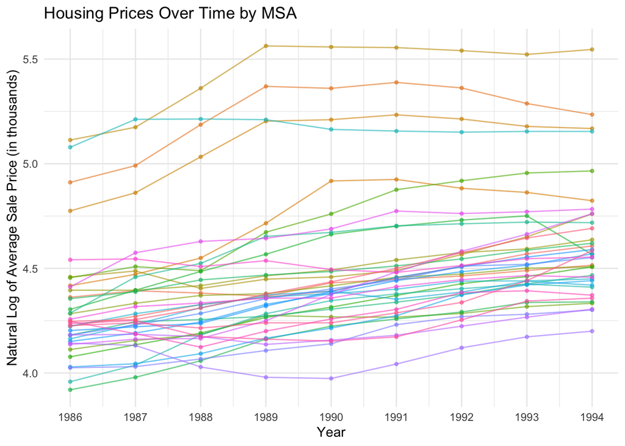

```r
ggplot(hprice, aes(x = time, y = narsp, group = msa, color = msa)) +
  geom_line(alpha = 0.6) +
  geom_point(size = 1, alpha = 0.6) +
  scale_x_continuous(breaks = 1:9, labels = 1986:1994) +
  labs(title = "Housing Prices Over Time by MSA",
       x = "Year",
       y = "Natural Log of Average Sale Price (in thousands)",
       color = "MSA") +
  theme_minimal() +
  theme(legend.position = "none")
```

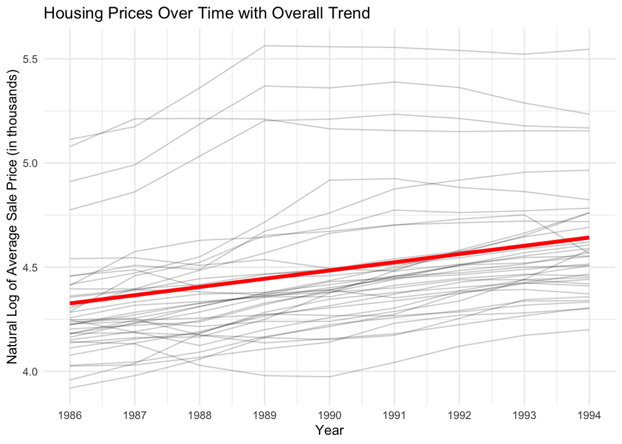

```r
ggplot(hprice, aes(x = time, y = narsp)) +
  geom_line(aes(group = msa), alpha = 0.2) +
  geom_smooth(method = "gam",
              formula = y ~ s(x, k = 5),
              se = FALSE,
              color = "red",
              size = 1.5) +
  scale_x_continuous(breaks = 1:9, labels = 1986:1994) +
  labs(title = "Housing Prices Over Time with Overall Trend",
       x = "Year",
       y = "Natural Log of Average Sale Price (in thousands)") +
  theme_minimal()
```

2. Fit a linear model with the (log) house price as the response and all other variables (except msa) as fixed effect predictors. Which terms are statistically significant? Discuss the coefficient for time.

**Solution**

A linear model was fit with the log of average house price (narsp) as the response variable and all other variables (ypc, perypc, regtest, rcdum, ajwtr, and time) as predictors. The model summary reveals that the statistically significant terms (p-value below 0.05) are ypc, perypc, regtest, rcdum1, and time. In other words, all predictors except ajwtr are statistically significant in explaining the variation in housing prices.

The coefficient for time is -0.0177 has the interpretation: after controlling for average per capita income, percentage growth in per capita income, regulatory environment index, rent control status, and adjacency to a coastline, the natural log of average housing sale prices declined by approximately 0.0177 units each year from 1986 to 1994. On the original price scale (in thousands of dollars), this corresponds to an estimated 1.75% annual decrease (calculated as e^-0.0177 = 0.9824 or a 1.75% decline per year). Thus, even after accounting for key economic and regulatory factors, housing prices trended downward on average during this period.

```r
lm_model <- lm(narsp ~ ypc + perypc + regtest + rcdum + ajwtr + time,
               data = hprice)
summary(lm_model)
```

```
Call:
lm(formula = narsp ~ ypc + perypc + regtest + rcdum + ajwtr +
    time, data = hprice)

Residuals:
    Min      1Q  Median      3Q     Max
-0.3139 -0.1081 -0.0152  0.0855  0.5559

Coefficients:
             Estimate Std. Error t value Pr(>|t|)
(Intercept)  2.67e+00   8.46e-02   31.61  < 2e-16 ***
ypc          7.03e-05   4.36e-06   16.13  < 2e-16 ***
perypc      -1.37e-02   5.07e-03   -2.70  0.00722 **
regtest      2.95e-02   3.10e-03    9.52  < 2e-16 ***
rcdum1       1.49e-01   3.24e-02    4.60  6.1e-06 ***
ajwtr1       3.59e-02   2.00e-02    1.80  0.07348 .
time        -1.77e-02   5.13e-03   -3.45  0.00065 ***
---
Signif. codes:  0 '***' 0.001 '**' 0.01 '*' 0.05 '.' 0.1 ' ' 1

Residual standard error: 0.165 on 317 degrees of freedom
Multiple R-squared:  0.757, Adjusted R-squared:  0.753
F-statistic:  165 on 6 and 317 DF,  p-value: <2e-16
```

3. Make a plot that shows how per-capita income changes over time. What is the nature of the increase? Make a similar plot to show how income growth changes over time. Comment on the plot.

**Solution**

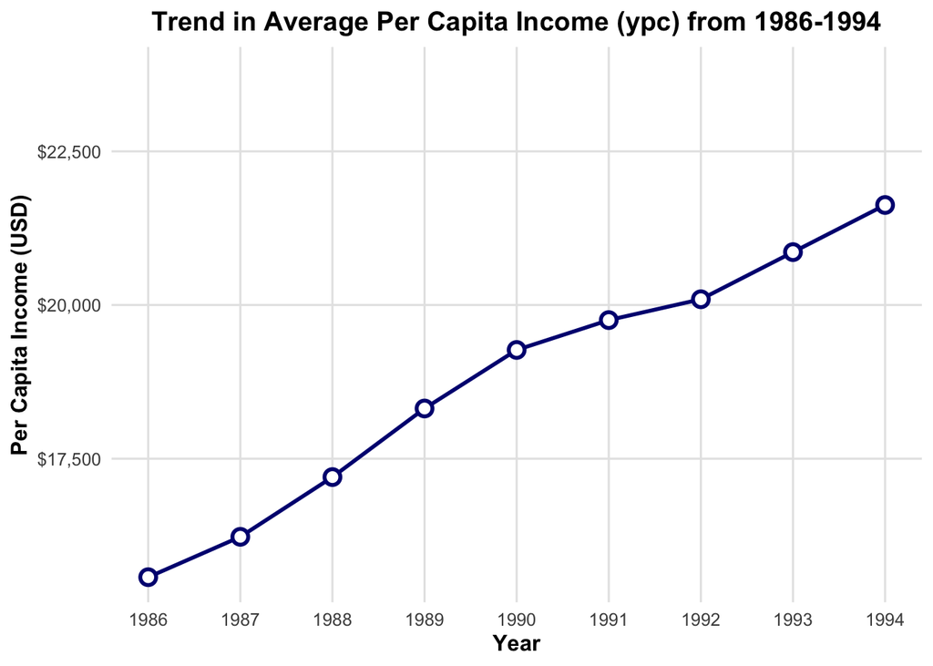

```r
ypc_summary <- hprice %>%
  group_by(time) %>%
  summarise(
    mean_ypc = mean(ypc, na.rm = TRUE),
  )

ggplot(ypc_summary, aes(x = time, y = mean_ypc)) +
  geom_line(size = 1, color = "navy") +
  geom_point(size = 3, shape = 21, fill = "white", color = "navy", stroke = 1.5) +
  scale_x_continuous(breaks = 1:9,
                     labels = 1986:1994,
                     minor_breaks = NULL) +
  scale_y_continuous(labels = scales::dollar_format(),
                     limits = c(NA, max(ypc_summary$mean_ypc) * 1.1)) +
  labs(
    title = "Trend in Average Per Capita Income (ypc) from 1986-1994",
    x = "Year",
    y = "Per Capita Income (USD)",
  ) +
  theme_minimal(base_size = 12) +
  theme(
    panel.grid.major = element_line(color = "grey90"),
    panel.grid.minor = element_blank(),
    plot.title = element_text(face = "bold", hjust = 0.5),
    plot.subtitle = element_text(hjust = 0.5, color = "grey40"),
    axis.title = element_text(face = "bold")
  )
```

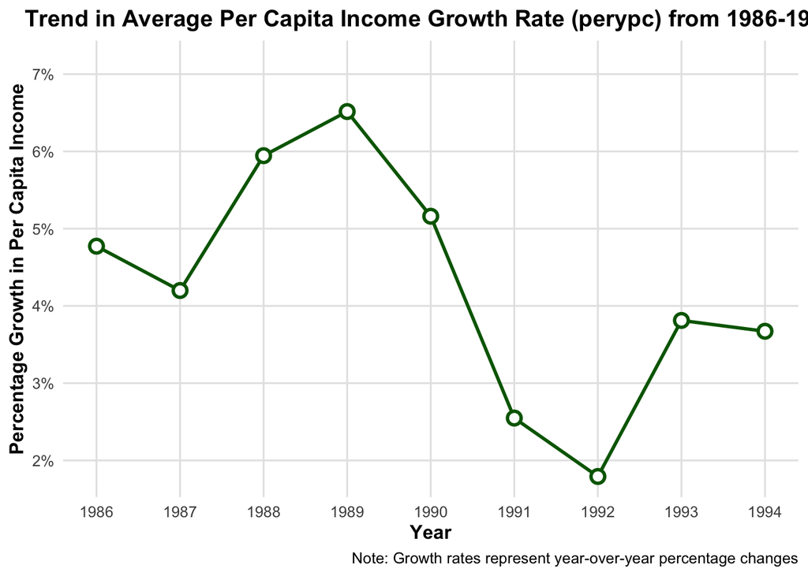

```r
perypc_summary <- hprice %>%
  group_by(time) %>%
  summarise(
    mean_perypc = mean(perypc, na.rm = TRUE)
  )

# Create the plot
ggplot(perypc_summary, aes(x = time, y = mean_perypc)) +
  geom_line(size = 1, color = "darkgreen") +
  geom_point(size = 3, shape = 21, fill = "white", color = "darkgreen", stroke = 1.5) +
  scale_x_continuous(breaks = 1:9,
                     labels = 1986:1994,
                     minor_breaks = NULL) +
  scale_y_continuous(labels = scales::percent_format(scale = 1),
                     limits = c(NA, max(perypc_summary$mean_perypc) * 1.1)) +
  labs(
    title = "Trend in Average Per Capita Income Growth Rate (perypc) from 1986-1994",
    x = "Year",
    y = "Percentage Growth in Per Capita Income",
    caption = "Note: Growth rates represent year-over-year percentage changes"
  ) +
  theme_minimal(base_size = 12) +
  theme(
    panel.grid.major = element_line(color = "grey90"),
    panel.grid.minor = element_blank(),
    plot.title = element_text(face = "bold", hjust = 0.5),
    plot.subtitle = element_text(hjust = 0.5, color = "grey40"),
    axis.title = element_text(face = "bold")
  )
```

4. Create a new variable that is the per-capita income for the first time period for each MSA. Refit the same linear model but now using the initial income and not the income as it changes over time. Compare the two models.

**Soltuion** We conducted a model comparison to evaluate whether initial per capita income, represented by a new variable initial_ypc (capturing each MSA’s income in the first year, 1986), could serve as an effective substitute for the original time-varying per capita income (ypc) in explaining log average housing prices (narsp). Both models included the same set of predictors: income growth (perypc), regulatory environment index (regtest), rent control indicator (rcdum1), adjacency to coastline (ajwtr1), and time (time). The only distinction between the two models was whether they used ypc or initial_ypc as the income predictor.

Comparing the performance metrics of the two models, we found that the model using initial_ypc outperformed the original across various metrics. The initial income model achieved a higher R-squared value of 0.766 compared to 0.757 for the original model, indicating that it explains a greater proportion of the variation in housing prices. Its adjusted R-squared was also slightly higher (0.762 vs. 0.753), and it yielded a notably lower AIC value (-251 vs. -239), which suggests a better-fitting and more parsimonious model. These results imply that initial income is not only a valid substitute but may actually be a more stable and informative predictor of average housing prices across MSAs than annually fluctuating income.

Overall, these findings suggest that initial per capita income captures long-term economic conditions more effectively than annual fluctuations, making it a more robust and interpretable predictor of housing price levels over time.

```r
hprice <- hprice %>%
  group_by(msa) %>%
  mutate(initial_ypc = first(ypc[time == 1])) %>%
  ungroup()

original_model <- lm(narsp ~ ypc + perypc + regtest + rcdum + ajwtr + time,
                     data = hprice)
summary(original_model)
```

```
Call:
lm(formula = narsp ~ ypc + perypc + regtest + rcdum + ajwtr +
    time, data = hprice)

Residuals:
    Min      1Q  Median      3Q     Max
-0.3139 -0.1081 -0.0152  0.0855  0.5559

Coefficients:
             Estimate Std. Error t value Pr(>|t|)
(Intercept)  2.67e+00   8.46e-02   31.61  < 2e-16 ***
ypc          7.03e-05   4.36e-06   16.13  < 2e-16 ***
perypc      -1.37e-02   5.07e-03   -2.70  0.00722 **
regtest      2.95e-02   3.10e-03    9.52  < 2e-16 ***
rcdum1       1.49e-01   3.24e-02    4.60  6.1e-06 ***
ajwtr1       3.59e-02   2.00e-02    1.80  0.07348 .
time        -1.77e-02   5.13e-03   -3.45  0.00065 ***
---
Signif. codes:  0 '***' 0.001 '**' 0.01 '*' 0.05 '.' 0.1 ' ' 1

Residual standard error: 0.165 on 317 degrees of freedom
Multiple R-squared:  0.757, Adjusted R-squared:  0.753
F-statistic:  165 on 6 and 317 DF,  p-value: <2e-16
```

```r
initial_income_model <- lm(narsp ~ initial_ypc + perypc + regtest + rcdum + ajwtr + time,
                          data = hprice)

summary(initial_income_model)
```

```
Call:
lm(formula = narsp ~ initial_ypc + perypc + regtest + rcdum +
    ajwtr + time, data = hprice)

Residuals:
    Min      1Q  Median      3Q     Max
-0.3728 -0.1055 -0.0154  0.0790  0.5391

Coefficients:
             Estimate Std. Error t value Pr(>|t|)
(Intercept)  2.30e+00   9.67e-02   23.80  < 2e-16 ***
initial_ypc  8.87e-05   5.28e-06   16.81  < 2e-16 ***
perypc      -8.13e-03   4.97e-03   -1.64     0.10
regtest      3.01e-02   3.04e-03    9.93  < 2e-16 ***
rcdum1       1.51e-01   3.16e-02    4.78  2.7e-06 ***
ajwtr1       3.85e-02   1.96e-02    1.97     0.05 .
time         3.71e-02   3.79e-03    9.80  < 2e-16 ***
---
Signif. codes:  0 '***' 0.001 '**' 0.01 '*' 0.05 '.' 0.1 ' ' 1

Residual standard error: 0.162 on 317 degrees of freedom
Multiple R-squared:  0.766, Adjusted R-squared:  0.762
F-statistic:  173 on 6 and 317 DF,  p-value: <2e-16
```

```r
model_comparison <- list(
  "Original Model (Time-Varying Income)" = tidy(original_model),
  "Initial Income Model" = tidy(initial_income_model)
) %>%
  bind_rows(.id = "Model") %>%
  dplyr::select(Model, term, estimate, std.error, p.value) %>%
  mutate(
    across(c(estimate, std.error), ~round(., 5)),
    p.value = ifelse(p.value < 0.001, "<0.001", round(p.value, 3))
  )

kable(model_comparison, caption = "Comparison of Models with Time-Varying vs Initial Income")
```

Comparison of Models with Time-Varying vs Initial Income

| Model | term | estimate | std.error | p.value |
| --- | --- | --- | --- | --- |
| Original Model (Time-Varying Income) | (Intercept) | 2.6731 | 0.0846 | <0.001 |
| Original Model (Time-Varying Income) | ypc | 0.0001 | 0.0000 | <0.001 |
| Original Model (Time-Varying Income) | perypc | -0.0137 | 0.0051 | 0.007 |
| Original Model (Time-Varying Income) | regtest | 0.0295 | 0.0031 | <0.001 |
| Original Model (Time-Varying Income) | rcdum1 | 0.1488 | 0.0323 | <0.001 |
| Original Model (Time-Varying Income) | ajwtr1 | 0.0359 | 0.0200 | 0.073 |
| Original Model (Time-Varying Income) | time | -0.0177 | 0.0051 | <0.001 |
| Initial Income Model | (Intercept) | 2.3003 | 0.0967 | <0.001 |
| Initial Income Model | initial_ypc | 0.0001 | 0.0000 | <0.001 |
| Initial Income Model | perypc | -0.0081 | 0.0050 | 0.103 |
| Initial Income Model | regtest | 0.0301 | 0.0030 | <0.001 |
| Initial Income Model | rcdum1 | 0.1512 | 0.0316 | <0.001 |
| Initial Income Model | ajwtr1 | 0.0385 | 0.0196 | 0.05 |
| Initial Income Model | time | 0.0371 | 0.0038 | <0.001 |

```r
fit_stats <- data.frame(
  Model = c("Original Model (Time-Varying Income)", "Initial Income Model"),
  R_squared = c(summary(original_model)$r.squared, summary(initial_income_model)$r.squared),
  Adj_R_squared = c(summary(original_model)$adj.r.squared, summary(initial_income_model)$adj.r.squared),
  AIC = c(AIC(original_model), AIC(initial_income_model))
)

kable(fit_stats, caption = "Model Fit Statistics (R², Adjusted R², AIC)")
```

Model Fit Statistics (R², Adjusted R², AIC)

| Model | R_squared | Adj_R_squared | AIC |
| --- | --- | --- | --- |
| Original Model (Time-Varying Income) | 0.7572 | 0.7526 | -239.0 |
| Initial Income Model | 0.7662 | 0.7618 | -251.3 |

5. Fit a mixed effects model that has a random intercept for each MSA. Why might this be reasonable? The rest of the model should have the same structure as in the previous question. Make a numerical interpretation of the coefficient of time in your model. Explain the difference between REML and MLE methods.

**Solution**

We fit a mixed-effects model using lmer() with REML, incorporating a random intercept for each MSA. This approach is appropriate given that our dataset includes repeated measurements for the same MSAs over a nine-year period (1986–1994), which introduces within-group correlations that violate the independence assumption of standard linear models. As observed in Part 1, plotting the natural log of average sale prices over time revealed that different MSAs exhibit distinct baseline housing price levels. By including a random intercept, we allow each MSA to have its own baseline housing price level while assuming that the effects of the other predictors remain constant across MSAs (i.e., fixed slopes). This modeling structure accounts for intra-class correlation—the natural similarity of observations within the same MSA—which helps prevent the underestimation of standard errors, inflation of Type I error rates, and overly narrow confidence intervals.

```r
hprice <- hprice %>%
  mutate(across(c(initial_ypc, perypc, regtest, time), ~ as.numeric(scale(.x))))

lmm_model <- lmer(narsp ~ initial_ypc + perypc + regtest + rcdum + ajwtr + time +
                    (1 | msa),
                  data = hprice, REML = TRUE)
summary(lmm_model)
```

```
Linear mixed model fit by REML. t-tests use Satterthwaite's method [
lmerModLmerTest]
Formula: narsp ~ initial_ypc + perypc + regtest + rcdum + ajwtr + time +
    (1 | msa)
   Data: hprice

REML criterion at convergence: -602.1

Scaled residuals:
   Min     1Q Median     3Q    Max
-2.385 -0.594 -0.025  0.574  2.858

Random effects:
 Groups   Name        Variance Std.Dev.
 msa      (Intercept) 0.02361  0.1537
 Residual             0.00545  0.0738
Number of obs: 324, groups:  msa, 36

Fixed effects:
             Estimate Std. Error        df t value Pr(>|t|)
(Intercept)   4.44708    0.03578  30.99980  124.27  < 2e-16 ***
initial_ypc   0.17732    0.03042  30.99994    5.83  2.0e-06 ***
perypc       -0.01803    0.00453 286.41026   -3.98  8.7e-05 ***
regtest       0.10104    0.02930  31.00113    3.45   0.0016 **
rcdum1        0.15137    0.09111  31.00081    1.66   0.1067
ajwtr1        0.03853    0.05647  30.99974    0.68   0.5001
time          0.09517    0.00447 286.06515   21.28  < 2e-16 ***
---
Signif. codes:  0 '***' 0.001 '**' 0.01 '*' 0.05 '.' 0.1 ' ' 1

Correlation of Fixed Effects:
            (Intr) intl_y perypc regtst rcdum1 ajwtr1
initial_ypc  0.237
perypc       0.001  0.002
regtest      0.136 -0.174 -0.005
rcdum1      -0.237 -0.332 -0.004 -0.310
ajwtr1      -0.595 -0.182  0.001 -0.040 -0.178
time         0.000  0.001  0.395 -0.002 -0.002  0.000
```

REML versus MLE: The key difference between REML and MLE lies in how they estimate the variance components of a mixed-effects model. REML estimates variance components after accounting for the fixed effects, adjusting for the degrees of freedom lost in estimating those fixed effects. This adjustment makes REML better suited for inference about random effects, as it produces less biased estimates of variance components. However, a limitation of REML is that it cannot be used to compare models with different fixed-effects structures.

In our REML-fitted model, the variance of the random intercept for MSA was estimated at 0.02361, and the residual variance was 0.00545. These values reflect the variability across MSAs and within observations, respectively, after adjusting for fixed effects. In contrast, when the model was fit using MLE (by setting REML = FALSE), the variance of the MSA random intercept decreased to 0.02025, and the residual variance slightly decreased to 0.00541. This highlights an issue with MLE where it tends to underestimate variance components, particularly for random effects, because it does not adjust for the loss of degrees of freedom from estimating fixed effects. Instead, MLE estimates all model parameters (fixed and random effects) simultaneously, making it more appropriate for model comparison purposes, such as using AIC or likelihood ratio tests. Therefore, in this example, we can conclude that REML is the preferred method for estimating and interpreting model effects, as it provides less biased estimates of the random MSA intercepts. This is important given the relatively small number of clusters (36 MSAs), where REML’s adjustment for the loss of degrees of freedom is important in producing more reliable variance estimates.

Despite the differences in variance estimates, the fixed-effect estimates remained remarkably stable across both methods. For example, the coefficients for time and initial_ypc were nearly identical between the REML and MLE models. Other coefficients showed slight variation, but the overall structure and interpretation of the fixed effects were consistent.

```r
lmm_model_mle <- lmer(narsp ~ initial_ypc + perypc + regtest + rcdum + ajwtr + time +
                        (1 | msa),
                      data = hprice, REML = FALSE)
summary(lmm_model_mle)
```

```
Linear mixed model fit by maximum likelihood . t-tests use Satterthwaite's
  method [lmerModLmerTest]
Formula: narsp ~ initial_ypc + perypc + regtest + rcdum + ajwtr + time +
    (1 | msa)
   Data: hprice

      AIC       BIC    logLik -2*log(L)  df.resid
   -625.8    -591.8     321.9    -643.8       315

Scaled residuals:
    Min      1Q  Median      3Q     Max
-2.4035 -0.5959 -0.0374  0.5812  2.8706

Random effects:
 Groups   Name        Variance Std.Dev.
 msa      (Intercept) 0.02025  0.1423
 Residual             0.00541  0.0736
Number of obs: 324, groups:  msa, 36

Fixed effects:
             Estimate Std. Error        df t value Pr(>|t|)
(Intercept)   4.44708    0.03321  35.99973  133.92  < 2e-16 ***
initial_ypc   0.17732    0.02823  35.99992    6.28  2.9e-07 ***
perypc       -0.01802    0.00451 288.47477   -3.99  8.3e-05 ***
regtest       0.10104    0.02719  36.00151    3.72  0.00068 ***
rcdum1        0.15137    0.08455  36.00109    1.79  0.08182 .
ajwtr1        0.03853    0.05240  35.99965    0.74  0.46695
time          0.09518    0.00446 288.07393   21.36  < 2e-16 ***
---
Signif. codes:  0 '***' 0.001 '**' 0.01 '*' 0.05 '.' 0.1 ' ' 1

Correlation of Fixed Effects:
            (Intr) intl_y perypc regtst rcdum1 ajwtr1
initial_ypc  0.237
perypc       0.001  0.002
regtest      0.136 -0.174 -0.005
rcdum1      -0.237 -0.332 -0.005 -0.310
ajwtr1      -0.595 -0.182  0.001 -0.040 -0.178
time         0.000  0.001  0.395 -0.002 -0.002  0.000
```

6. Fit a model that omits the adjacent to water and rent control predictors. Test whether this reduction in the model can be supported.

**Solution** The reduced model below omits the predictors for adjacency to water and rent control. Compared to the original full model, it still models the natural logarithm of average house sale prices, while retaining the same random intercept for MSAs to account for baseline differences across regions. It also includes the same set of continuous predictors: initial_ypc (baseline per capita income), perypc (income growth rate), regtest (regulatory environment index), and time.

```r
full_model <- lmer(narsp ~ initial_ypc + perypc + regtest + rcdum + ajwtr + time +
                  (1 | msa),
                  data = hprice,
                  REML = TRUE)
summary(full_model)
```

```
Linear mixed model fit by REML. t-tests use Satterthwaite's method [
lmerModLmerTest]
Formula: narsp ~ initial_ypc + perypc + regtest + rcdum + ajwtr + time +
    (1 | msa)
   Data: hprice

REML criterion at convergence: -602.1

Scaled residuals:
   Min     1Q Median     3Q    Max
-2.385 -0.594 -0.025  0.574  2.858

Random effects:
 Groups   Name        Variance Std.Dev.
 msa      (Intercept) 0.02361  0.1537
 Residual             0.00545  0.0738
Number of obs: 324, groups:  msa, 36

Fixed effects:
             Estimate Std. Error        df t value Pr(>|t|)
(Intercept)   4.44708    0.03578  30.99980  124.27  < 2e-16 ***
initial_ypc   0.17732    0.03042  30.99994    5.83  2.0e-06 ***
perypc       -0.01803    0.00453 286.41026   -3.98  8.7e-05 ***
regtest       0.10104    0.02930  31.00113    3.45   0.0016 **
rcdum1        0.15137    0.09111  31.00081    1.66   0.1067
ajwtr1        0.03853    0.05647  30.99974    0.68   0.5001
time          0.09517    0.00447 286.06515   21.28  < 2e-16 ***
---
Signif. codes:  0 '***' 0.001 '**' 0.01 '*' 0.05 '.' 0.1 ' ' 1

Correlation of Fixed Effects:
            (Intr) intl_y perypc regtst rcdum1 ajwtr1
initial_ypc  0.237
perypc       0.001  0.002
regtest      0.136 -0.174 -0.005
rcdum1      -0.237 -0.332 -0.004 -0.310
ajwtr1      -0.595 -0.182  0.001 -0.040 -0.178
time         0.000  0.001  0.395 -0.002 -0.002  0.000
```

```r
reduced_model <- lmer(narsp ~ initial_ypc + perypc + regtest + time +
                     (1 | msa),
                     data = hprice,
                     REML = TRUE)
summary(reduced_model)
```

```
Linear mixed model fit by REML. t-tests use Satterthwaite's method [
lmerModLmerTest]
Formula: narsp ~ initial_ypc + perypc + regtest + time + (1 | msa)
   Data: hprice

REML criterion at convergence: -605.3

Scaled residuals:
    Min      1Q  Median      3Q     Max
-2.3793 -0.5958 -0.0131  0.5801  2.8500

Random effects:
 Groups   Name        Variance Std.Dev.
 msa      (Intercept) 0.02489  0.1578
 Residual             0.00545  0.0738
Number of obs: 324, groups:  msa, 36

Fixed effects:
             Estimate Std. Error        df t value Pr(>|t|)
(Intercept)   4.48416    0.02661  32.99935  168.49  < 2e-16 ***
initial_ypc   0.20147    0.02844  32.99937    7.08  4.1e-08 ***
perypc       -0.01800    0.00453 286.39898   -3.97  8.9e-05 ***
regtest       0.11894    0.02844  33.00195    4.18    2e-04 ***
time          0.09518    0.00447 286.06303   21.28  < 2e-16 ***
---
Signif. codes:  0 '***' 0.001 '**' 0.01 '*' 0.05 '.' 0.1 ' ' 1

Correlation of Fixed Effects:
            (Intr) intl_y perypc regtst
initial_ypc  0.000
perypc       0.000  0.000
regtest      0.000 -0.349 -0.006
time         0.000  0.000  0.395 -0.002
```

Comparison between the Full and Reduced Model Observations:

Table Visualizing Contrasting Measurements betwen the Two Models:

```r
full_summary <- broom.mixed::tidy(full_model, effects = "fixed") %>%
  mutate(Model = "Full Model")

reduced_summary <- broom.mixed::tidy(reduced_model, effects = "fixed") %>%
  mutate(Model = "Reduced Model")

coef_table <- bind_rows(full_summary, reduced_summary) %>%
  dplyr::select(Model, term, estimate, std.error, statistic, p.value) %>%
  mutate(
    across(c(estimate, std.error, statistic), ~ round(.x, 4)),
    p.value = ifelse(p.value < 0.001, "<0.001", round(p.value, 3))
  )

kable(coef_table, caption = "Comparison of Fixed Effects Between Full and Reduced Models")
```

Comparison of Fixed Effects Between Full and Reduced Models

| Model | term | estimate | std.error | statistic | p.value |
| --- | --- | --- | --- | --- | --- |
| Full Model | (Intercept) | 4.4471 | 0.0358 | 124.2732 | <0.001 |
| Full Model | initial_ypc | 0.1773 | 0.0304 | 5.8296 | <0.001 |
| Full Model | perypc | -0.0180 | 0.0045 | -3.9812 | <0.001 |
| Full Model | regtest | 0.1010 | 0.0293 | 3.4481 | 0.002 |
| Full Model | rcdum1 | 0.1514 | 0.0911 | 1.6613 | 0.107 |
| Full Model | ajwtr1 | 0.0385 | 0.0565 | 0.6823 | 0.5 |
| Full Model | time | 0.0952 | 0.0045 | 21.2822 | <0.001 |
| Reduced Model | (Intercept) | 4.4842 | 0.0266 | 168.4907 | <0.001 |
| Reduced Model | initial_ypc | 0.2015 | 0.0284 | 7.0842 | <0.001 |
| Reduced Model | perypc | -0.0180 | 0.0045 | -3.9749 | <0.001 |
| Reduced Model | regtest | 0.1189 | 0.0284 | 4.1822 | <0.001 |
| Reduced Model | time | 0.0952 | 0.0045 | 21.2846 | <0.001 |

```r
re_full <- as.data.frame(VarCorr(full_model))
re_reduced <- as.data.frame(VarCorr(reduced_model))

re_full <- re_full %>%
  mutate(Model = "Full Model") %>%
  rename(
    grp = grp,
    term = var1,
    Variance = vcov,
    Std_Dev = sdcor
  ) %>%
  dplyr::select(Model, grp, term, Variance, Std_Dev)

re_reduced <- re_reduced %>%
  mutate(Model = "Reduced Model") %>%
  rename(
    grp = grp,
    term = var1,
    Variance = vcov,
    Std_Dev = sdcor
  ) %>%
  dplyr::select(Model, grp, term, Variance, Std_Dev)


random_effects_table <- bind_rows(re_full, re_reduced)

random_effects_table <- random_effects_table %>%
  mutate(
    Variance = round(Variance, 5),
    Std_Dev = round(Std_Dev, 5)
  )

kable(random_effects_table, caption = "Comparison of Random Effects (Variance and Std. Dev) for Full and Reduced Models")
```

Comparison of Random Effects (Variance and Std. Dev) for Full and Reduced Models

| Model | grp | term | Variance | Std_Dev |
| --- | --- | --- | --- | --- |
| Full Model | msa | (Intercept) | 0.0236 | 0.1537 |
| Full Model | Residual | NA | 0.0054 | 0.0738 |
| Reduced Model | msa | (Intercept) | 0.0249 | 0.1578 |
| Reduced Model | Residual | NA | 0.0054 | 0.0738 |

We performed a Kenward-Roger (KR) test to compare the full and reduced models. This test is used to approximate the degrees of freedom when testing fixed effects in linear mixed-effects models. The KR method is particularly valuable because it addresses bias in the estimation of degrees of freedom by adjusting the denominator degrees of freedom to account for the uncertainty introduced by estimating random effects. This adjustment is especially important when the number of clusters (in this case, 36 MSAs) is relatively small or moderate. The results of the test show a p-value of 0.17, which is greater than the conventional significance threshold of 0.05. As a result, we fail to reject the null hypothesis, indicating that there is no statistically significant difference in model fit between the full model and the reduced model that omits the two predictors: rent control (rcdum) and adjacency to water (ajwtr). Therefore, we conclude that the reduced model provides a more parsimonious, yet statistically equivalent, alternative to the full model.

```r
kr_test <- KRmodcomp(full_model, reduced_model)
summary(kr_test)
```

```
F-test with Kenward-Roger approximation; time: 0.05 sec
large : narsp ~ initial_ypc + perypc + regtest + rcdum + ajwtr + time +
    (1 | msa)
small : narsp ~ initial_ypc + perypc + regtest + time + (1 | msa)
        stat   ndf   ddf F.scaling p.value
Ftest   1.87  2.00 31.00         1    0.17
FtestU  1.87  2.00 31.00              0.17
```

7. It is possible that the increase in prices may not be linear in year. Fit an additive mixed model where smooth is added to year. Make a plot to show how prices have increased over time.

**Solution** We fit an additive mixed model using gam() to allow for the possibility that the increase in housing prices over time is nonlinear. The model includes fixed effects for baseline income (initial_ypc), income growth (perypc), regulatory environment (regtest), rent control (rcdum), and coastal proximity (ajwtr). To capture potential nonlinear time trends, we added a smooth term for time, modeled as a cubic regression spline with five basis functions (k = 5). Additionally, a random intercept for MSA was included using s(msa, bs = “re”), accounting for baseline differences in average housing prices across metropolitan areas.

From the model output, the smooth term for time has an effective degrees of freedom (edf) of 2.69, which is greater than 1, confirming a nonlinear relationship between time and housing prices. This suggests we should expect to see accelerating or decelerating trends, rather than a constant rate of change over time. The smooth term for msa has an edf of 30.25, which is close to the number of MSAs (36), indicating substantial between-region variability—or equivalently, that nearly all MSAs require unique intercepts to accurately capture baseline differences. Both smooth terms have very small p-values, indicating that both the nonlinear time trend and the regional heterogeneity are statistically significant.

The model’s adjusted R-squared is 0.952, meaning it explains 95.2% of the variance in the response variable (log average housing prices). The deviance explained is 95.8%, and the REML criterion is –305.85. While these values suggest the model fits the data very well and captures nearly all systematic variation, it remains important to check residual diagnostics to ensure that the underlying model assumptions (such as homoscedasticity, normality, independence) are satisfied.

```r
gamm_model <- gam(narsp ~ initial_ypc + perypc + regtest + rcdum + ajwtr +
                  s(time, bs = "cr", k = 5) +
                  s(msa, bs = "re"),
                data = hprice,
                method = "REML")
summary(gamm_model)
```

```
Family: gaussian
Link function: identity

Formula:
narsp ~ initial_ypc + perypc + regtest + rcdum + ajwtr + s(time,
    bs = "cr", k = 5) + s(msa, bs = "re")

Parametric coefficients:
            Estimate Std. Error t value Pr(>|t|)
(Intercept)  4.44704    0.03580  124.23  < 2e-16 ***
initial_ypc  0.17727    0.03043    5.83  1.5e-08 ***
perypc      -0.02204    0.00491   -4.49  1.0e-05 ***
regtest      0.10116    0.02931    3.45  0.00064 ***
rcdum1       0.15171    0.09115    1.66  0.09712 .
ajwtr1       0.03850    0.05649    0.68  0.49607
---
Signif. codes:  0 '***' 0.001 '**' 0.01 '*' 0.05 '.' 0.1 ' ' 1

Approximate significance of smooth terms:
          edf Ref.df     F p-value
s(time)  2.69    3.2 148.2  <2e-16 ***
s(msa)  30.25   31.0  40.6  <2e-16 ***
---
Signif. codes:  0 '***' 0.001 '**' 0.01 '*' 0.05 '.' 0.1 ' ' 1

R-sq.(adj) =  0.952   Deviance explained = 95.8%
-REML = -305.85  Scale est. = 0.005239  n = 324
```

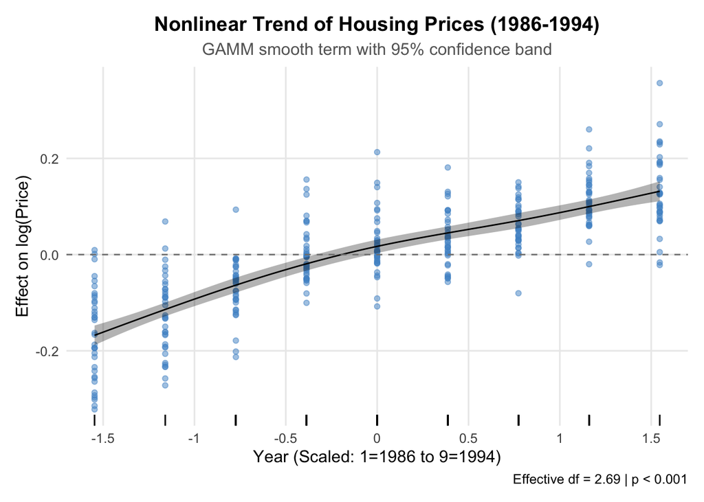

```r
time_plot <- draw(gamm_model,
                 select = "s(time)",
                 residuals = TRUE,
                 ci_alpha = 0.3,
                 rug = TRUE) +
  labs(
    title = "Nonlinear Trend of Housing Prices (1986-1994)",
    subtitle = "GAMM smooth term with 95% confidence band",
    x = "Year (Scaled: 1=1986 to 9=1994)",
    y = "Effect on log(Price)",
    caption = paste("Effective df =", round(summary(gamm_model)$s.table["s(time)", "edf"], 2),
                   "| p < 0.001")
  ) +
  theme_minimal(base_size = 12) +
  theme(
    plot.title = element_text(face = "bold", hjust = 0.5),
    plot.subtitle = element_text(hjust = 0.5, color = "grey40"),
    panel.grid.minor = element_blank()
  ) +
  scale_x_continuous(breaks = seq(-1.5, 1.5, by = 0.5),
                    labels = function(x) round(mean(hprice$time) + x * sd(hprice$time), 1)) +
  geom_hline(yintercept = 0, linetype = "dashed", color = "grey50")

print(time_plot)
```

8. Interpret the coefficients in the previous model for the initial annual income, growth and regulation predictors.

**Solution**

## 4 Optional Midterm Make-up*

Rework on your midterm exam. Your final midterm grade will be the average of your original (in class) midterm and this make-up one.